# Lab5

Stephanie Gluck

February 13, 2020

```r
library(rio)
library(tidyverse)
```

```r
library(ggplot2)
library(here)
library(scales)
library(janitor)
library(ggrepel)
library(gghighlight)
library(ggtext)
```

https://www.kaggle.com/noriuk/us-education-datasets-unification-project

```r
pth <- here("states_all.csv")
d <- import(pth) %>% clean_names() %>%
  mutate(state = str_to_title(state))
```

## Part 1

### 1. Reproduce Plot

```r
p1_d <- d %>% select(state, year, ends_with("revenue"), -total_revenue) %>%
  pivot_longer(ends_with("revenue"), names_to = "revenue_type", values_to = "revenue")

head(p1_d)
```

```
## # A tibble: 6 x 4
##   state    year revenue_type    revenue
##   <chr>   <int> <chr>             <dbl>
## 1 Alabama  1992 federal_revenue  304177
## 2 Alabama  1992 state_revenue   1659028
## 3 Alabama  1992 local_revenue    715680
## 4 Alaska   1992 federal_revenue  106780
## 5 Alaska   1992 state_revenue    720711
## 6 Alaska   1992 local_revenue    222100
```

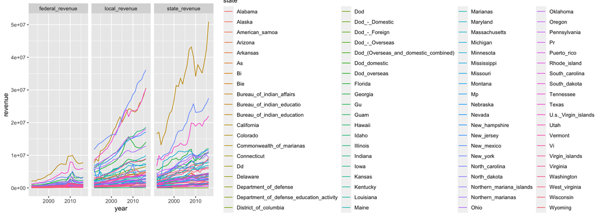

```r
ggplot(p1_d, aes(year, revenue)) +
  geom_line(aes(color = state)) +
  facet_wrap(~revenue_type)
```

I noticed when I first plot the data, an error was generated that told me it removed 534 rows that had missing values. I thought it would be good to remove those rows for subsequent visualization.

### 2. Plot Improvement

The legend with all the states in different colors makes the plot extremely diffuclt to understand and the colors that correspond to each state is difficult to distinguish. Instead of having all the states by different colors, a stronger visualization could have all the sates in one color and selectively highlight particular states of interest as it comes to revenue (e.g., states with highest and lowest federal, local and state revenue, or highlist the state that one resides in) or the addition of a trend line to show the average change in revenue over time.

Overall, the data appears to skew to the right with most states reporting at the lower end of the revenue. Log transformation applied to the Y axis (revenue) may help better visualize the revenue across each state over time.

The current Y axis values are denoted in scientic notation which makes it difficult to understand. Converting the Y-axis to to dollars would be the more appropriate and fitting to the revenue data. The X axis title could be removed as year is intuitive and could be gleaned if a figure title was included.

### 3. Revised Plot

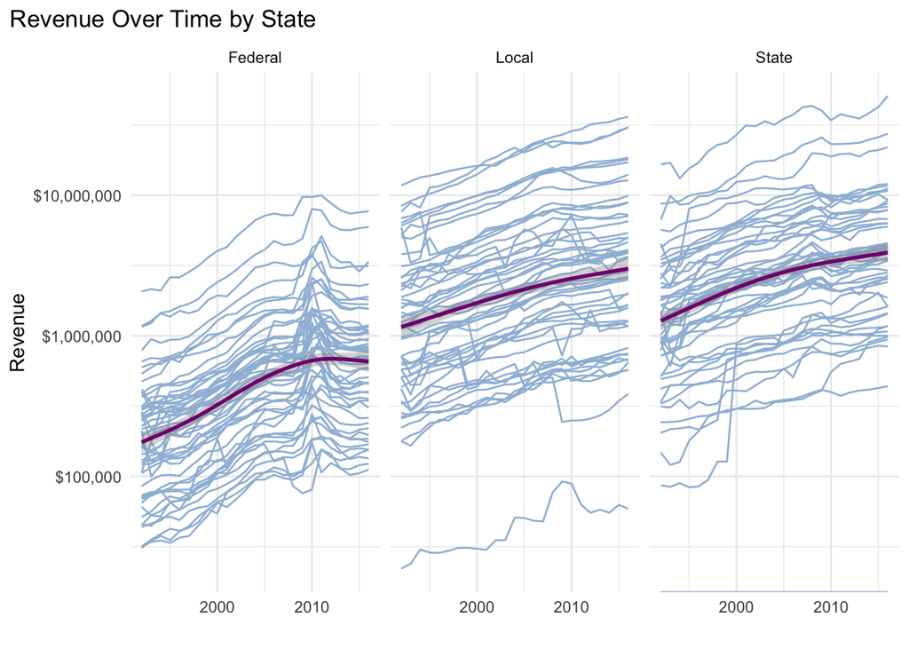

```r
p1_d_revised <- p1_d %>% drop_na() %>%
  mutate(revenue_type = as.factor(revenue_type)) %>%
  mutate(revenue_type = recode(revenue_type,
                               "federal_revenue" = "Federal",
                               "local_revenue" = "Local",
                               "state_revenue" = "State"))

ggplot(p1_d_revised, aes(year, revenue)) +
  geom_line(aes(group = state),
            color = "#9ebcda") +
  scale_y_log10(labels = scales::dollar) +
  geom_smooth(group = "state", color = "#810f7c") +
  facet_wrap(~revenue_type) +
  theme_minimal() +
  labs(x = "",
       y = "Revenue",
       title = "Revenue Over Time by State") +
  theme(plot.title.position = "plot")
```

### Revised plot ideal version

I wanted to use gghighlight to highlight the state with the highest and lowest revenue for each facet (state, local, federal) but was having diffulty getting the result I wanted in ggplot. I included 2 attempts that produced varying result and highlights.

Also, I would have liked to still include the trend line even after using gghighlight. However simply adding geom_smooth() within my codes produced an error.

```r
p1_d_revised %>% group_by(revenue_type) %>% summarize(max = max(revenue),
                                              min = min(revenue))
```

```
## # A tibble: 3 x 3
##   revenue_type      max   min
##   <fct>           <dbl> <dbl>
## 1 Federal       9990221 31020
## 2 Local        36105265 22093
## 3 State        50904567     0
```

```
## label_key: state
```

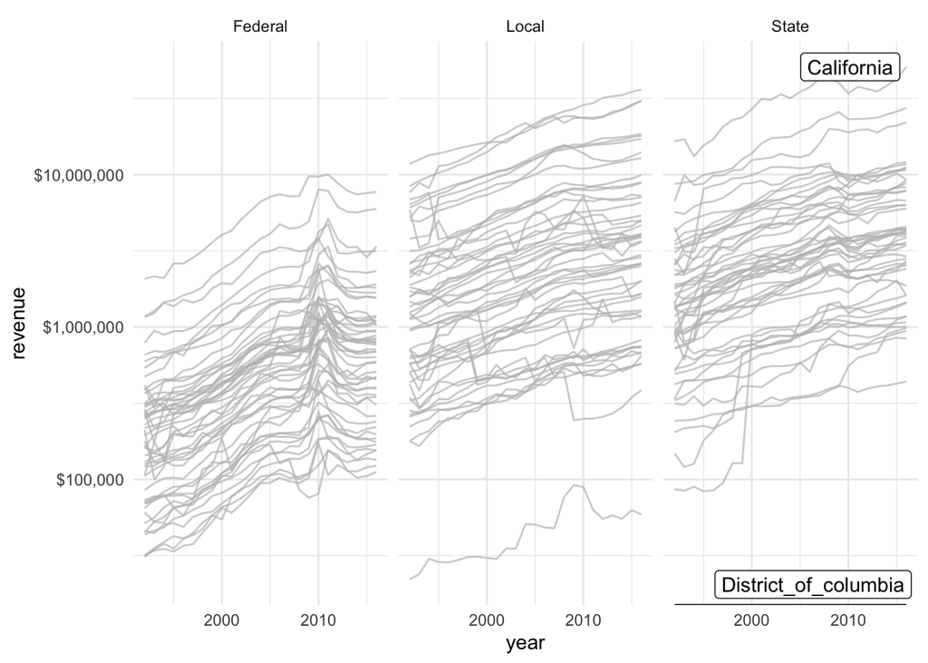

```r
ggplot(p1_d_revised) +
  geom_line(aes(x = year, y = revenue, group = state)) +
  scale_y_log10(labels = scales::dollar) +
  facet_wrap(~revenue_type) +
  gghighlight(revenue == min(revenue) | revenue == max(revenue),
              calculate_per_facet = T, max_highlight = 1) +
  theme_minimal()
```

```
## label_key: state
```

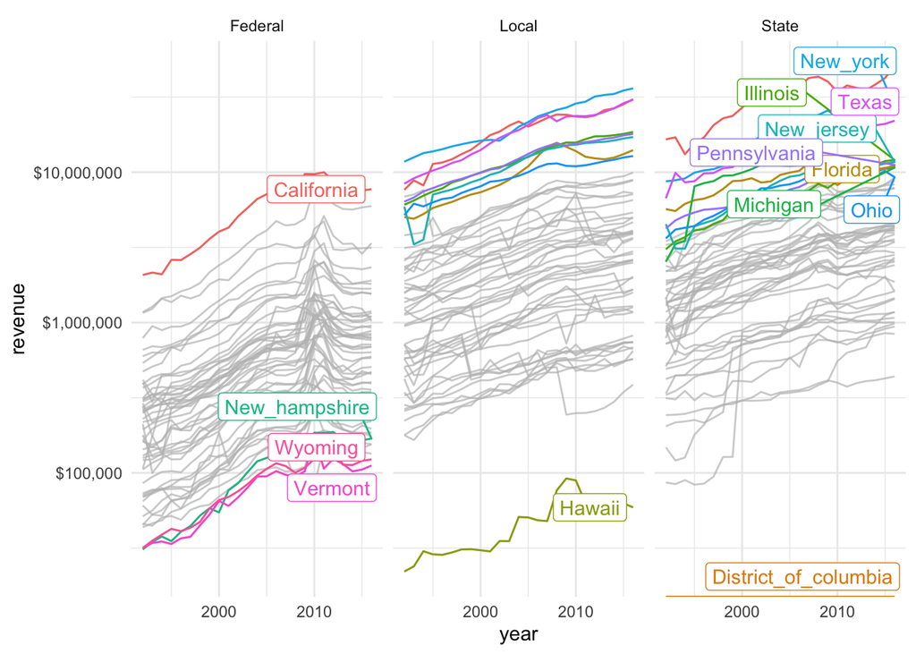

```r
ggplot(p1_d_revised) +
  geom_line(aes(x = year, y = revenue, color = state)) +
  scale_y_log10(labels = scales::dollar) +
  facet_wrap(~revenue_type) +
  gghighlight(max_highlight = 1, min(revenue) < 32000 | max(revenue) > 9990100,
              calculate_per_facet = T) +
  theme_minimal()
```

## Part 2

Stephanie comment: I wanted to extract only the subject (math or reading) after pivot_longer so I googled up a regular expression to extract values in between underscores, but I have no idea what the expression is actually doing, it was more of a plug and play and see what works.

```r
p2_d <- d %>% select(state, year, total_revenue, enroll, ends_with("score")) %>%
  drop_na(-state, -year) %>%
  pivot_longer(ends_with("score"), names_to = "content", values_to = "score") %>%
  mutate(content = sub("(.*?_){1}(.*?)($|_.*)", "\\2", content)) %>%
  mutate(content = as.factor(content)) %>%
  mutate(content = recode(content,
                               "math" = "Math",
                               "reading" = "Reading"))

p2_d_summary <- p2_d %>% group_by(state, content) %>%
  summarise(avg_revenue = mean(total_revenue/enroll),
            avg_score = mean(score)) %>%
  ungroup() %>%
  mutate(state = gsub("_", " ", state),
         state = str_to_title(state))

head(p2_d_summary)
```

```
## # A tibble: 6 x 4
##   state   content avg_revenue avg_score
##   <chr>   <fct>         <dbl>     <dbl>
## 1 Alabama Math           8.35      245.
## 2 Alabama Reading        8.35      239.
## 3 Alaska  Math          16.1       259.
## 4 Alaska  Reading       16.1       238.
## 5 Arizona Math           8.01      253.
## 6 Arizona Reading        8.01      237.
```

```r
tail(p2_d_summary)
```

```
## # A tibble: 6 x 4
##   state         content avg_revenue avg_score
##   <chr>         <fct>         <dbl>     <dbl>
## 1 West Virginia Math           10.6      252.
## 2 West Virginia Reading        10.6      240.
## 3 Wisconsin     Math           11.6      264.
## 4 Wisconsin     Reading        11.6      244.
## 5 Wyoming       Math           15.8      263.
## 6 Wyoming       Reading        15.8      243.
```

### Reproduce Plot

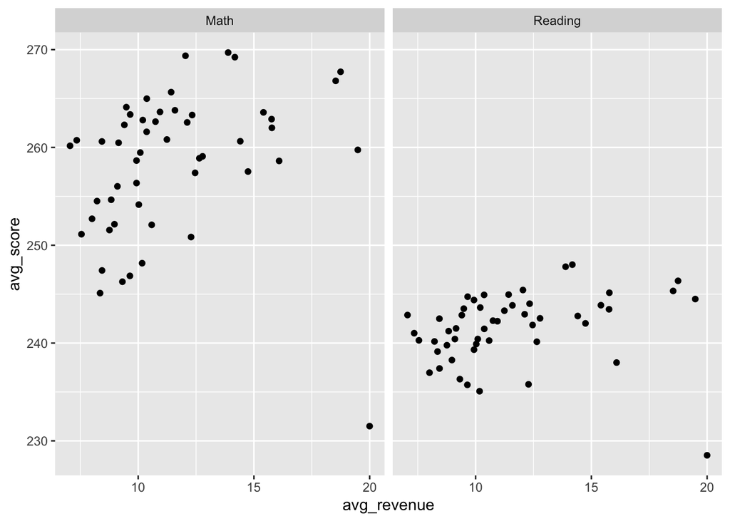

```r
ggplot(p2_d_summary, aes(avg_revenue, avg_score)) +
  geom_point() +
  facet_wrap(~ content)
```

### Improve Plot

```r
top_revenue <- p2_d_summary %>%
  top_n(10, wt = avg_revenue)
top_revenue
```

```
## # A tibble: 10 x 4
##    state                content avg_revenue avg_score
##    <chr>                <fct>         <dbl>     <dbl>
##  1 Alaska               Math           16.1      259.
##  2 Alaska               Reading        16.1      238.
##  3 District Of Columbia Math           20.0      232.
##  4 District Of Columbia Reading        20.0      229.
##  5 New Jersey           Math           18.7      268.
##  6 New Jersey           Reading        18.7      246.
##  7 New York             Math           19.5      260.
##  8 New York             Reading        19.5      244.
##  9 Vermont              Math           18.5      267.
## 10 Vermont              Reading        18.5      245.
```

```r
low_revenue <- p2_d_summary %>%
  top_n(-10, wt = avg_revenue)
low_revenue
```

```
## # A tibble: 10 x 4
##    state     content avg_revenue avg_score
##    <chr>     <fct>         <dbl>     <dbl>
##  1 Arizona   Math           8.01      253.
##  2 Arizona   Reading        8.01      237.
##  3 Idaho     Math           7.35      261.
##  4 Idaho     Reading        7.35      241.
##  5 Oklahoma  Math           8.22      255.
##  6 Oklahoma  Reading        8.22      240.
##  7 Tennessee Math           7.55      251.
##  8 Tennessee Reading        7.55      240.
##  9 Utah      Math           7.06      260.
## 10 Utah      Reading        7.06      243.
```

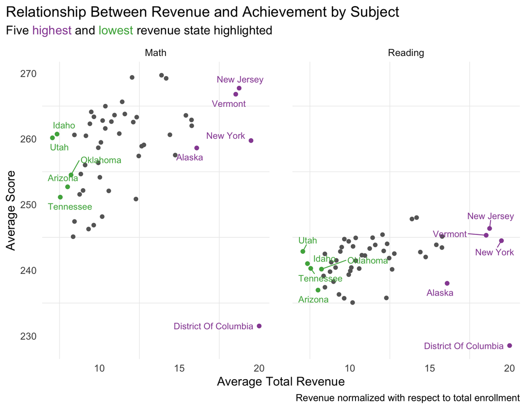

```r
ggplot(p2_d_summary, aes(avg_revenue, avg_score)) +
  geom_point(color = "gray40", size = 2) +
  geom_point(data = top_revenue,
             aes(avg_revenue, avg_score),
             color = "#984ea3", size = 2) +
  geom_point(data = low_revenue,
             aes(avg_revenue, avg_score),
             color = "#4daf4a", size = 2) +
  geom_text_repel(data = top_revenue,
                  aes(label = state),
                  color = "#984ea3",
                  box.padding = unit(.5, 'lines')) +
  geom_text_repel(data = low_revenue,
                  aes(label = state),
                  color = "#4daf4a",
                  box.padding = unit(.5, 'lines')) +
  facet_wrap(~ content) +
  theme_minimal(base_size = 15) +
  theme(panel.spacing = unit(1, "cm")) +
  scale_color_brewer(palette = "Dark2") +
  labs(x = "Average Total Revenue",
       y = "Average Score",
       title = "Relationship Between Revenue and Achievement by Subject",
       subtitle = "Five <span style = 'color : #984ea3'>highest</span> and
       <span style = 'color : #4daf4a'>lowest</span> revenue state highlighted",
       caption = "Revenue normalized with respect to total enrollment") +
    theme(panel.grid.major = element_blank(),
          plot.title.position = "plot",
          plot.subtitle = element_markdown())
```